# Business Intelligence Lab Submission Markdown

Lumin

1/10/23

# Student Details

[output not shown]

# Setup Chunk

**Note:** the following “*KnitR*” options have been set as the defaults:  
`knitr::opts_chunk$set(echo = TRUE, warning = FALSE, eval = TRUE, collapse = FALSE, tidy.opts = list(width.cutoff = 80), tidy = TRUE)`.

More KnitR options are documented here https://bookdown.org/yihui/rmarkdown-cookbook/chunk-options.html and here https://yihui.org/knitr/options/.

**Note:** the following “*R Markdown*” options have been set as the defaults:

> output:  
> github_document:  
> toc: yes  
> toc_depth: 4  
> fig_width: 6  
> fig_height: 4  
> df_print: default  
> editor_options:  
> chunk_output_type: console

# Step 1: Install and Load Required Packages:

In this step, we ensure that the necessary R packages are installed and loaded. Packages are collections of R functions, data, and compiled code that extend the functionality of R. The install.packages() function is used to install packages, and library() is used to load them.

```r
# Consider a library as the location where packages are stored.  Execute the
# following command to list all the libraries available in your computer:
.libPaths()
```

```
## [1] "/home/ki3ani/R/x86_64-pc-linux-gnu-library/4.1"
## [2] "/usr/local/lib/R/site-library"
## [3] "/usr/lib/R/site-library"
## [4] "/usr/lib/R/library"
```

```r
# One of the libraries should be a folder inside the project if you are using
# renv

# Then execute the following command to see which packages are available in
# each library:
lapply(.libPaths(), list.files)
```

[output not shown]

[output cut: 49 more lines]

```r
# If renv::restore() did not install the 'languageserver' package (required to
# use R for VS Code), then it can be installed manually as follows (restart R
# after executing the command):
if (!is.element("languageserver", installed.packages()[, 1])) {
    install.packages("languageserver", dependencies = TRUE)
}
require("languageserver")
## dplyr - For data manipulation ----
if (!is.element("dplyr", installed.packages()[, 1])) {
    install.packages("dplyr", dependencies = TRUE)
}
require("dplyr")
```

```r
## ggplot2 - For data visualizations using the Grammar for Graphics package
## ----
if (!is.element("ggplot2", installed.packages()[, 1])) {
    install.packages("ggplot2", dependencies = TRUE)
}
require("ggplot2")
## ggrepel - Additional options for the Grammar for Graphics package ----
if (!is.element("ggrepel", installed.packages()[, 1])) {
    install.packages("ggrepel", dependencies = TRUE)
}
require("ggrepel")
## ggraph - Additional options for the Grammar for Graphics package ----
if (!is.element("ggraph", installed.packages()[, 1])) {
    install.packages("ggraph", dependencies = TRUE)
}
require("ggraph")
## tidytext - For text mining ----
if (!is.element("tidytext", installed.packages()[, 1])) {
    install.packages("tidytext", dependencies = TRUE)
}
require("tidytext")
## tidyr - To tidy messy data ----
if (!is.element("tidyr", installed.packages()[, 1])) {
    install.packages("tidyr", dependencies = TRUE)
}
require("tidyr")
## widyr - To widen, process, and re-tidy a dataset ----
if (!is.element("widyr", installed.packages()[, 1])) {
    install.packages("widyr", dependencies = TRUE)
}
require("widyr")
## gridExtra - to arrange multiple grid-based plots on a page ----
if (!is.element("gridExtra", installed.packages()[, 1])) {
    install.packages("gridExtra", dependencies = TRUE)
}
require("gridExtra")
## knitr - for dynamic report generation ----
if (!is.element("knitr", installed.packages()[, 1])) {
    install.packages("knitr", dependencies = TRUE)
}
require("knitr")
## kableExtra - for nicely formatted output tables ----
if (!is.element("kableExtra", installed.packages()[, 1])) {
    install.packages("kableExtra", dependencies = TRUE)
}
require("kableExtra")
## formattable - To create a formattable object ---- A formattable object is an
## object to which a formatting function and related attributes are attached.
if (!is.element("formattable", installed.packages()[, 1])) {
    install.packages("formattable", dependencies = TRUE)
}
require("formattable")
## circlize - To create a cord diagram or visualization ---- by Gu et al.
## (2014)
if (!is.element("circlize", installed.packages()[, 1])) {
    install.packages("circlize", dependencies = TRUE)
}
require("circlize")
## memery - For creating data analysis related memes ---- The memery package
## generates internet memes that optionally include a superimposed inset plot
## and other atypical features, combining the visual impact of an
## attention-grabbing meme with graphic results of data analysis.
if (!is.element("memery", installed.packages()[, 1])) {
    install.packages("memery", dependencies = TRUE)
}
require("memery")
## magick - For image processing in R ----
if (!is.element("magick", installed.packages()[, 1])) {
    install.packages("magick", dependencies = TRUE)
}
require("magick")
## yarrr - To create a pirate plot ----
if (!is.element("yarrr", installed.packages()[, 1])) {
    install.packages("yarrr", dependencies = TRUE)
}
require("yarrr")
## radarchart - To create interactive radar charts using ChartJS ----
if (!is.element("radarchart", installed.packages()[, 1])) {
    install.packages("radarchart", dependencies = TRUE)
}
require("radarchart")
## igraph - To create ngram network diagrams ----
if (!is.element("igraph", installed.packages()[, 1])) {
    install.packages("igraph", dependencies = TRUE)
}
require("igraph")
## wordcloud2 - For creating wordcloud by using 'wordcloud2.JS ----
if (!is.element("wordcloud2", installed.packages()[, 1])) {
    install.packages("wordcloud2", dependencies = TRUE)
}
require("wordcloud2")
## readr - Load datasets from CSV files ----
if (!is.element("readr", installed.packages()[, 1])) {
    install.packages("readr", dependencies = TRUE)
}
require("readr")
library(readr)
```

# Step 2: Customize the Visualizations, Tables, and Colour Scheme:

```r
# STEP 2. Customize the Visualizations, Tables, and Colour Scheme ---- The
# following defines a blue-grey colour scheme for the visualizations: shades of
# blue and shades of grey
blue_grey_colours_11 <- c("#27408E", "#304FAF", "#536CB5", "#6981c7", "#8da0db",
    "#dde5ec", "#c8c9ca", "#B9BCC2", "#A7AAAF", "#888A8E", "#636569")

blue_grey_colours_6 <- c("#27408E", "#304FAF", "#536CB5", "#B9BCC2", "#A7AAAF", "#888A8E")

blue_grey_colours_4 <- c("#27408E", "#536CB5", "#B9BCC2", "#888A8E")

blue_grey_colours_2 <- c("#27408E", "#888A8E")

blue_grey_colours_1 <- c("#6981c7")

# Custom theme for visualizations
blue_grey_theme <- function() {
    theme(axis.ticks = element_line(linewidth = 1, linetype = "dashed", lineend = NULL,
        color = "#dfdede", arrow = NULL, inherit.blank = FALSE), axis.text = element_text(face = "bold",
        color = "#3f3f41", size = 12, hjust = 0.5), axis.title = element_text(face = "bold",
        color = "#3f3f41", size = 14, hjust = 0.5), plot.title = element_text(face = "bold",
        color = "#3f3f41", size = 16, hjust = 0.5), panel.grid = element_line(linewidth = 0.1,
        linetype = "dashed", lineend = NULL, color = "#dfdede", arrow = NULL, inherit.blank = FALSE),
        panel.background = element_rect(fill = "#f3eeee"), legend.title = element_text(face = "plain",
            color = "#3f3f41", size = 12, hjust = 0), legend.position = "right")
}

# Customize the text tables for consistency using HTML formatting
kable_theme <- function(dat, caption) {
    kable(dat, "html", escape = FALSE, caption = caption) %>%
        kable_styling(bootstrap_options = c("striped", "condensed", "bordered"),
            full_width = FALSE)
}

library(readr)
```

# Step 3: Load the Dataset:

```r
student_performance_dataset <- read_csv("/home/ki3ani/BBT4206-R-Lab2b-of15-EDAForQualitativeData-lumin/markdown/performance-dataset.csv",
    col_types = cols(class_group = col_factor(levels = c("A", "B", "C")), gender = col_factor(levels = c("1",
        "0")), YOB = col_date(format = "%Y"), regret_choosing_bi = col_factor(levels = c("1",
        "0")), drop_bi_now = col_factor(levels = c("1", "0")), motivator = col_factor(levels = c("1",
        "0")), read_content_before_lecture = col_factor(levels = c("1", "2", "3",
        "4", "5")), anticipate_test_questions = col_factor(levels = c("1", "2", "3",
        "4", "5")), answer_rhetorical_questions = col_factor(levels = c("1", "2",
        "3", "4", "5")), find_terms_I_do_not_know = col_factor(levels = c("1", "2",
        "3", "4", "5")), copy_new_terms_in_reading_notebook = col_factor(levels = c("1",
        "2", "3", "4", "5")), take_quizzes_and_use_results = col_factor(levels = c("1",
        "2", "3", "4", "5")), reorganise_course_outline = col_factor(levels = c("1",
        "2", "3", "4", "5")), write_down_important_points = col_factor(levels = c("1",
        "2", "3", "4", "5")), space_out_revision = col_factor(levels = c("1", "2",
        "3", "4", "5")), studying_in_study_group = col_factor(levels = c("1", "2",
        "3", "4", "5")), schedule_appointments = col_factor(levels = c("1", "2",
        "3", "4", "5")), goal_oriented = col_factor(levels = c("1", "0")), spaced_repetition = col_factor(levels = c("1",
        "2", "3", "4")), testing_and_active_recall = col_factor(levels = c("1", "2",
        "3", "4")), interleaving = col_factor(levels = c("1", "2", "3", "4")), categorizing = col_factor(levels = c("1",
        "2", "3", "4")), retrospective_timetable = col_factor(levels = c("1", "2",
        "3", "4")), cornell_notes = col_factor(levels = c("1", "2", "3", "4")), sq3r = col_factor(levels = c("1",
        "2", "3", "4")), commute = col_factor(levels = c("1", "2", "3", "4")), study_time = col_factor(levels = c("1",
        "2", "3", "4")), repeats_since_Y1 = col_integer(), paid_tuition = col_factor(levels = c("0",
        "1")), free_tuition = col_factor(levels = c("0", "1")), extra_curricular = col_factor(levels = c("0",
        "1")), sports_extra_curricular = col_factor(levels = c("0", "1")), exercise_per_week = col_factor(levels = c("0",
        "1", "2", "3")), meditate = col_factor(levels = c("0", "1", "2", "3")), pray = col_factor(levels = c("0",
        "1", "2", "3")), internet = col_factor(levels = c("0", "1")), laptop = col_factor(levels = c("0",
        "1")), family_relationships = col_factor(levels = c("1", "2", "3", "4", "5")),
        friendships = col_factor(levels = c("1", "2", "3", "4", "5")), romantic_relationships = col_factor(levels = c("0",
            "1", "2", "3", "4")), spiritual_wellnes = col_factor(levels = c("1",
            "2", "3", "4", "5")), financial_wellness = col_factor(levels = c("1",
            "2", "3", "4", "5")), health = col_factor(levels = c("1", "2", "3", "4",
            "5")), day_out = col_factor(levels = c("0", "1", "2", "3")), night_out = col_factor(levels = c("0",
            "1", "2", "3")), alcohol_or_narcotics = col_factor(levels = c("0", "1",
            "2", "3")), mentor = col_factor(levels = c("0", "1")), mentor_meetings = col_factor(levels = c("0",
            "1", "2", "3")), `Attendance Waiver Granted: 1 = Yes, 0 = No` = col_factor(levels = c("0",
            "1")), GRADE = col_factor(levels = c("A", "B", "C", "D", "E"))), locale = locale())

View(student_performance_dataset)

# Dimensions
dim(student_performance_dataset)
```

```
## [1] 101 100
```

```r
# Data Types
sapply(student_performance_dataset, class)
```

[output not shown]

[output cut: 183 more lines]

```r
glimpse(student_performance_dataset)
```

```
## Rows: 101
## Columns: 100
## $ class_group                                                                                                                                                                                                                                                                                     <fct> …
## $ gender                                                                                                                                                                                                                                                                                          <fct> …
## $ YOB                                                                                                                                                                                                                                                                                             <date> …
## $ regret_choosing_bi                                                                                                                                                                                                                                                                              <fct> …
## $ drop_bi_now                                                                                                                                                                                                                                                                                     <fct> …
## $ motivator                                                                                                                                                                                                                                                                                       <fct> …
## $ read_content_before_lecture                                                                                                                                                                                                                                                                     <fct> …
## $ anticipate_test_questions                                                                                                                                                                                                                                                                       <fct> …
## $ answer_rhetorical_questions                                                                                                                                                                                                                                                                     <fct> …
## $ find_terms_I_do_not_know                                                                                                                                                                                                                                                                        <fct> …
## $ copy_new_terms_in_reading_notebook                                                                                                                                                                                                                                                              <fct> …
## $ take_quizzes_and_use_results                                                                                                                                                                                                                                                                    <fct> …
## $ reorganise_course_outline                                                                                                                                                                                                                                                                       <fct> …
```

[output cut: 87 more lines]

```r
# Summary of each variable
summary(student_performance_dataset)
```

```
##  class_group gender      YOB             regret_choosing_bi drop_bi_now
##  A:23        1:58   Min.   :1998-01-01   1: 2               1: 2
##  B:37        0:43   1st Qu.:2000-01-01   0:99               0:99
##  C:41               Median :2001-01-01
##                     Mean   :2000-11-25
##                     3rd Qu.:2002-01-01
##                     Max.   :2003-01-01
##
##  motivator read_content_before_lecture anticipate_test_questions
##  1:76      1:11                        1: 5
##  0:25      2:25                        2: 6
##            3:47                        3:31
##            4:14                        4:43
##            5: 4                        5:16
##
##
##  answer_rhetorical_questions find_terms_I_do_not_know
##  1: 3                        1: 6
##  2:15                        2: 2
##  3:32                        3:30
##  4:38                        4:37
##  5:13                        5:26
##
##
##  copy_new_terms_in_reading_notebook take_quizzes_and_use_results
##  1: 5                               1: 4
##  2:10                               2: 5
##  3:24                               3:22
##  4:37                               4:32
##  5:25                               5:38
##
##
##  reorganise_course_outline write_down_important_points space_out_revision
##  1: 7                      1: 4                        1: 8
##  2:16                      2: 8                        2:17
##  3:28                      3:20                        3:34
##  4:32                      4:38                        4:28
##  5:18                      5:31                        5:14
##
##
```

[output cut: 361 more lines]

```
##  Min.   : 7.47                Min.   : 5.00
##  1st Qu.:20.44                1st Qu.:26.00
##  Median :24.58                Median :34.00
##  Mean   :24.53                Mean   :33.94
##  3rd Qu.:29.31                3rd Qu.:42.00
##  Max.   :35.08                Max.   :56.00
##                               NA's   :4
##  TOTAL = Coursework TOTAL + EXAM (100%) GRADE
##  Min.   : 7.47                          A:23
##  1st Qu.:45.54                          B:25
##  Median :58.69                          C:22
##  Mean   :57.12                          D:25
##  3rd Qu.:68.83                          E: 6
##  Max.   :87.72
##
```

```r
library(readr)
```

# Step 4: Create a Subset of the Data:

Sometimes, we don’t need all the data—just a part of it. This step is like picking only the candies you like from a big box.

```r
evaluation_per_group_per_gender <- student_performance_dataset %>% # nolint
  mutate(`Student's Gender` =
           ifelse(gender == 1, "Male", "Female")) %>%
  select(class_group, gender,
         `Student's Gender`, `Average Course Evaluation Rating`) %>%
  filter(!is.na(`Average Course Evaluation Rating`)) %>%
  group_by(class_group, `Student's Gender`) %>%
  summarise(average_evaluation_rating =
              mean(`Average Course Evaluation Rating`)) %>%
  arrange(desc(average_evaluation_rating), .by_group = TRUE)
# Plain tabular output
View(evaluation_per_group_per_gender)

# Decorated tabular output
evaluation_per_group_per_gender %>%
  rename(`Class Group` = class_group) %>%
  rename(`Average Course Evaluation Rating` = average_evaluation_rating) %>%
  select(`Class Group`, `Student's Gender`,
         `Average Course Evaluation Rating`) %>%
  mutate(`Average Course Evaluation Rating` =
           color_tile("#B9BCC2", "#536CB5")
           (`Average Course Evaluation Rating`)) %>%
  kable("html", escape = FALSE, align = "c",
        caption = "Course Evaluation Rating per Group and per Gender") %>%
  kable_styling(bootstrap_options =
                  c("striped", "condensed", "bordered"),
                full_width = FALSE)
```

Course Evaluation Rating per Group and per Gender

| Class Group | Student’s Gender | Average Course Evaluation Rating |
| --- | --- | --- |
| A | Female | 4.618190 |
| A | Male | 4.573423 |
| B | Female | 4.573431 |
| B | Male | 4.569174 |
| C | Female | 4.636370 |
| C | Male | 4.294362 |

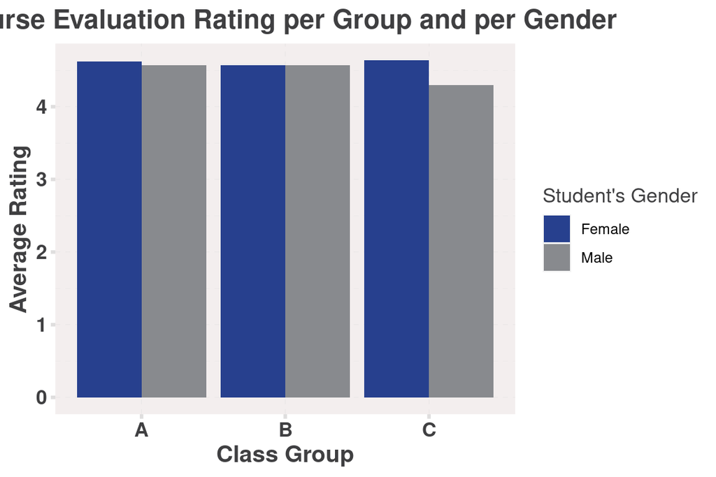

```r
# Decorated visual bar chart
evaluation_per_group_per_gender %>%
  ggplot() +
  geom_bar(aes(x = class_group, y = average_evaluation_rating,
               fill = `Student's Gender`),
           stat = "identity", position = "dodge") +
  expand_limits(y = 0) +
  blue_grey_theme() +
  scale_fill_manual(values = blue_grey_colours_2) +
  ggtitle("Course Evaluation Rating per Group and per Gender") +
  labs(x = "Class Group", y = "Average Rating")
```

```r
library(readr)
```

# Step 5: Data Cleansing for Qualitative Data:

This step involves cleaning up text data, which might involve removing unnecessary spaces, converting text to lowercase, or handling missing values.

```r
## Contractions ----

# Contractions in the English language are shortened forms of words or phrases
# created by combining two words and replacing one or more letters with an
# apostrophe ('), often for the purpose of making speech or writing more
# concise and informal. Contractions are often used in informal speech and
# writing but are generally avoided in formal writing, such as academic papers
# or business reports.

# A function to expand contractions in an English-language source (assuming
# that the students did not respond in sheng or Kiswahili).
expand_contractions <- function(doc) {
  doc <- gsub("I'm", "I am", doc, ignore.case = TRUE)
  doc <- gsub("you're", "you are", doc, ignore.case = TRUE)
  doc <- gsub("he's", "he is", doc, ignore.case = TRUE)
  doc <- gsub("she's", "she is", doc, ignore.case = TRUE)
  doc <- gsub("it's", "it is", doc, ignore.case = TRUE)
  doc <- gsub("we're", "we are", doc, ignore.case = TRUE)
  doc <- gsub("they're", "they are", doc, ignore.case = TRUE)
  doc <- gsub("I'll", "I will", doc, ignore.case = TRUE)
  doc <- gsub("you'll", "you will", doc, ignore.case = TRUE)
  doc <- gsub("he'll", "he will", doc, ignore.case = TRUE)
  doc <- gsub("she'll", "she will", doc, ignore.case = TRUE)
  doc <- gsub("it'll", "it will", doc, ignore.case = TRUE)
  doc <- gsub("we'll", "we will", doc, ignore.case = TRUE)
  doc <- gsub("they'll", "they will", doc, ignore.case = TRUE)
  doc <- gsub("won't", "will not", doc, ignore.case = TRUE)
  doc <- gsub("can't", "cannot", doc, ignore.case = TRUE)
  doc <- gsub("n't", " not", doc, ignore.case = TRUE)
  return(doc)
}

# Evaluation likes and wishes
evaluation_likes_and_wishes <- student_performance_dataset %>%
  mutate(`Student's Gender` =
           ifelse(gender == 1, "Male", "Female")) %>%
  rename(`Class Group` = class_group) %>%
  rename(Likes = `D - 1. \nWrite two things you like about the teaching and learning in this unit so far.`) %>% # nolint
  rename(Wishes = `D - 2. Write at least one recommendation to improve the teaching and learning in this unit (for the remaining weeks in the semester)`) %>% # nolint
  select(`Class Group`,
         `Student's Gender`, `Average Course Evaluation Rating`,
         Likes, Wishes) %>%
  filter(!is.na(`Average Course Evaluation Rating`)) %>%
  arrange(`Class Group`)

# Before expanding contractions (See row number 4)
View(evaluation_likes_and_wishes)

evaluation_likes_and_wishes$Likes <- sapply(evaluation_likes_and_wishes$Likes, expand_contractions) # nolint
evaluation_likes_and_wishes$Wishes <- sapply(evaluation_likes_and_wishes$Wishes, expand_contractions) # nolint

# After expanding contractions
View(evaluation_likes_and_wishes)

## Special Characters and Lower Case ----
# NOTE: The special characters should be removed *after* expanding the
# contractions

# A function to remove special characters
# Remember the use of regular expressions in the
# BBT3104: Advanced Database Systems course

# A tutorial on regular expressions: https://regexone.com/
# To test your regular expression: https://regexr.com/

remove_special_characters <- function(doc) {
  gsub("[^a-zA-Z0-9 ]", "", doc, ignore.case = TRUE)
}

# Before removing special characters (See row number 11)
View(evaluation_likes_and_wishes)

evaluation_likes_and_wishes$Likes <- sapply(evaluation_likes_and_wishes$Likes, remove_special_characters) # nolint
evaluation_likes_and_wishes$Wishes <- sapply(evaluation_likes_and_wishes$Wishes, remove_special_characters) # nolint

# Convert everything to lower case (to standardize the text)
evaluation_likes_and_wishes$Likes <- sapply(evaluation_likes_and_wishes$Likes, tolower) # nolint
evaluation_likes_and_wishes$Wishes <- sapply(evaluation_likes_and_wishes$Wishes, tolower) # nolint

# After removing special characters and converting everything to lower case
View(evaluation_likes_and_wishes)

# [OPTIONAL] You can save the file as a CSV at this point
write.csv(evaluation_likes_and_wishes,
          file = "/home/ki3ani/BBT4206-R-Lab2b-of15-EDAForQualitativeData-lumin/markdown/evaluation_likes_and_wishes.csv",
          row.names = FALSE)

# Additional examples can be seen here:
head(sample(stop_words$word, 20), 20)
```

```
##  [1] "you've"      "willing"     "showed"      "mean"        "over"
##  [6] "beyond"      "without"     "can't"       "opens"       "facts"
## [11] "meanwhile"   "have"        "accordingly" "next"        "exactly"
## [16] "them"        "things"      "i"           "who"         "perhaps"
```

```r
# You can also create a list of words that you would like to censor
undesirable_words <- c("wow", "lol", "none", "na")

evaluation_likes_filtered <- evaluation_likes_and_wishes %>% # nolint
  # We start by tokenization (unnesting words). This is from the variable
  # "Like" into the variable "word".
  unnest_tokens(word, Likes) %>%
  # Then we remove stopwords using an anti-join (remember this from the
  # BBT3104: Advanced Database Systems course)
  # Anti-join: do not join where the word is in the list of stopwords
  anti_join(stop_words, by = c("word")) %>%
  distinct() %>%
  # Censor or filter out unwanted words
  filter(!word %in% undesirable_words) %>%
  # Include only words that are more than 3 characters long (assuming that
  # these are the words that are meaningful)
  filter(nchar(word) > 3) %>%
  # We then rename the variable "word" for ease of use.
  rename(`Likes (tokenized)` = word) %>%
  # We focus only on the likes in this data frame
  select(-Wishes)

# Lastly, we save the created data frame as a CSV file:
write.csv(evaluation_likes_filtered,
          file = "/home/ki3ani/BBT4206-R-Lab2b-of15-EDAForQualitativeData-lumin/markdown/evaluation_likes_filtered.csv",
          row.names = FALSE)

# The same is done to create a data frame for the "wishes" only
evaluation_wishes_filtered <- evaluation_likes_and_wishes %>% # nolint
  unnest_tokens(word, Wishes) %>%
  anti_join(stop_words, by = c("word")) %>%
  distinct() %>%
  filter(!word %in% undesirable_words) %>%
  filter(nchar(word) > 3) %>%
  rename(`Wishes (tokenized)` = word) %>%
  select(-Likes)

write.csv(evaluation_wishes_filtered,
          file = "/home/ki3ani/BBT4206-R-Lab2b-of15-EDAForQualitativeData-lumin/markdown/evaluation_wishes_filtered.csv",
          row.names = FALSE)

library(readr)
```